# A Third Empirical Exploration of Machine Learning Concepts

## iris Data

[figure not shown]

```python
from sklearn import datasets
iris = datasets.load_iris()
```

iris is a dictionary with the following keys:

```python
iris.keys()
```

```
dict_keys(['data', 'target', 'frame', 'target_names', 'DESCR', 'feature_names', 'filename'])
```

```python
import pandas as pd
X = pd.DataFrame(iris.data, columns=['sepal length','sepal width', 'petal length','petal width'])
y = pd.Series(iris.target)
```

### Questions:

> 1. What is the domain set of the Iris dataset?
> 2. Consider only 2 dimensions: visualise the dataset and the classes
> 3. Recode the classes to get a binary classification problem :
>    - Iris setosa : -1
>    - Iris Versicolor & Iris Virginica : 1
> 4. Use the [perceptron algorithm](https://en.wikipedia.org/wiki/Perceptron), implemented in the scikit-learn library, to separate the 2 classes. Compute the empirical and generalization errors. Visualize the decision function (use the weights $w$).
> 5. Use the logistic regression algorithm to separate the 2 classes. Compute the empirical and generalization errors. Visualize the decision function (use the weights $w$).
> 6. Recode the classes
>    - Iris Virginica : -1
>    - Iris Setosa & Iris Versicolor : 1
> 7. Repeat the questions 4 and 5 for this classification problem

### Answers:

#### Question 1

The domain set ${\cal X}$ of Iris dataset is a subset of $\mathbb{R}^4$.

#### Question 2: Consider only 2 dimensions: visualise the dataset and the classes

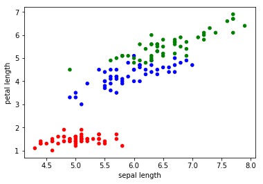

```python
%matplotlib inline
col = {0:"r", 1:"b", 2:"g"}
X.plot.scatter(x="sepal length", y="petal length", c=[col[e] for e in y])
```

#### Question 3 : Recode the classes to get a binary classification problem (separable case)

```python
ynew = y.replace([0,1,2],[-1,1,1])

Xtrain = X[["sepal width","petal length"]].sample(frac=0.5)
ytrain = ynew.loc[Xtrain.index] # The associated output
# test set = whole set \ train set
Xtest = X[["sepal width","petal length"]].loc[X.index.difference(Xtrain.index)]
ytest = ynew.loc[Xtest.index] # The associated output
```

#### Question 4: Perceptron

```python
from sklearn.linear_model import Perceptron
Perceptron?
```

```python
from sklearn.linear_model import Perceptron

pp = Perceptron()
pp.fit(Xtrain, ytrain)
```

```
Perceptron()
```

```python
from sklearn.metrics import zero_one_loss

yhat_train = pp.predict(Xtrain)

yhat_test = pp.predict(Xtest)

print("Empirical error:", zero_one_loss(yhat_train,ytrain))
print("Generalization error:", zero_one_loss(yhat_test,ytest))
```

```
Empirical error: 0.0
Generalization error: 0.0
```

```python
w=pp.coef_[0].tolist()
b = pp.intercept_[0]
w
```

```
[-5.1, 5.800000000000001]
```

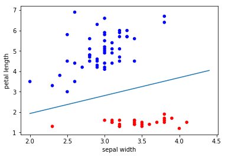

```python
import numpy as np
import matplotlib.pyplot as plt

absi = np.linspace(min(X["sepal width"]),max(X["sepal width"]),500)
ordo = -absi*w[0]/w[1]-b/w[1]

col = {-1:"r", 1:"b"}
Xtrain.plot.scatter(x="sepal width", y="petal length", c=[col[e] for e in ytrain])
plt.plot(absi,ordo)
```

#### Question 5: Logistic regression

```python
from sklearn.linear_model import LogisticRegression

logreg = LogisticRegression()
logreg.fit(Xtrain,ytrain)
```

```
LogisticRegression()
```

```python
yhat_train = logreg.predict(Xtrain)

yhat_test = logreg.predict(Xtest)

print("Empirical error:", zero_one_loss(yhat_train,ytrain))
print("Generalization error:", zero_one_loss(yhat_test,ytest))
```

```
Empirical error: 0.0
Generalization error: 0.0
```

```python
w=logreg.coef_[0].tolist()
b = logreg.intercept_[0]
w
```

```
[-0.785269227268032, 2.3156366388700595]
```

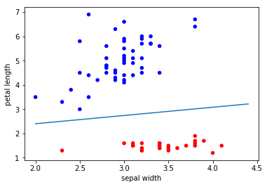

```python
absi = np.linspace(min(X["sepal width"]),max(X["sepal width"]),500)
ordo = -absi*w[0]/w[1]-b/w[1]

col = {-1:"r", 1:"b"}
Xtrain.plot.scatter(x="sepal width", y="petal length", c=[col[e] for e in ytrain])
plt.plot(absi,ordo)
```

#### Question 6 : Recode the classes to get a binary classification problem (non separble case)

```python
ynew = y.replace([0,1,2],[1,1,-1])

Xtrain = X[["sepal width","petal length"]].sample(frac=0.5)
ytrain = ynew.loc[Xtrain.index] # The associated output
Xtest = X[["sepal width","petal length"]].loc[X.index.difference(Xtrain.index)] # test set = whole set \ train set
ytest = ynew.loc[Xtest.index] # The associated output
```

#### Question 7

```python
pp = Perceptron()
pp.fit(Xtrain, ytrain)
```

```
Perceptron()
```

```python
yhat_train = pp.predict(Xtrain)

yhat_test = pp.predict(Xtest)

print("Empirical error:", zero_one_loss(yhat_train,ytrain))
print("Generalization error:", zero_one_loss(yhat_test,ytest))
```

```
Empirical error: 0.28
Generalization error: 0.33333333333333337
```

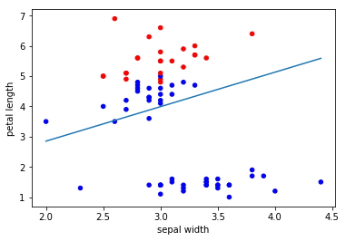

```python
w=pp.coef_[0].tolist()
b = pp.intercept_[0]
absi = np.linspace(min(X["sepal width"]),max(X["sepal width"]),500)
ordo = -absi*w[0]/w[1]-b/w[1]

col = {-1:"r", 1:"b"}
Xtrain.plot.scatter(x="sepal width", y="petal length", c=[col[e] for e in ytrain])
plt.plot(absi,ordo)
```

```python
logreg = LogisticRegression()
logreg.fit(Xtrain,ytrain)
yhat_train = logreg.predict(Xtrain)

yhat_test = logreg.predict(Xtest)

print("Empirical error:", zero_one_loss(yhat_train,ytrain))
print("Generalization error:", zero_one_loss(yhat_test,ytest))
```

```
Empirical error: 0.040000000000000036
Generalization error: 0.053333333333333344
```

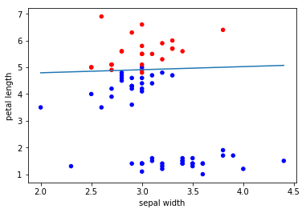

```python
w=logreg.coef_[0].tolist()
b = logreg.intercept_[0]
absi = np.linspace(min(X["sepal width"]),max(X["sepal width"]),500)
ordo = -absi*w[0]/w[1]-b/w[1]

col = {-1:"r", 1:"b"}
Xtrain.plot.scatter(x="sepal width", y="petal length", c=[col[e] for e in ytrain])
plt.plot(absi,ordo)
```